# unstruct_pop_models

2023-01-18

# 1 **Draft Outline**

# 2 **Module 1: Unstructured Population Models**

## 2.1 Introduction

This module covers the most simple models to predict the dynamics of populations, such as **exponential models**. Next, **stochasticity**, or random effects, is approached as affecting population dynamics. Then, **density-dependency** is introduced as a phenomena that takes place when the amount of individuals present in a given population interferes with the growth rate of that population. Lastly, you will learn techniques to compare models to data and perform **model assessment**.

## 2.2 Learning outcomes

- Develop practical skills to independently run a model using their own data based on provided theory and codes
- Assess the results of population models to analyze a problem of their interest
- Distinguish and compare several models and select the most appropriate model according to life histories and data available

### 2.2.1 What is a population model?

A population model consists of mathematical equations (eg., exponential and logistic) which represent patterns of growth, reduction, or stabilization of a given population.

### 2.2.2 Basic types of population models

- **Unstructured population model**: This model does not distinguish individuals counted as part of a given population.
- **Structured population model**: In this type of model, individuals are categorized (eg., by age) and then counted.
- **Density-independent model**: In more simple population models, the amount of individuals present at a given time do not interfere with reproduction success.
- **Density-dependent model**: This model considers that the growth rate of a given population depends on the amount of individuals living at a given time.

## 2.3 Simple models of population dynamics

### 2.3.1 Historical facts

In 1798, Thomas Malthus published *An Essay on the Principle of Population* (Malthus, 1798). This work distinguished arithmetic and geometric growth, with human populations characterized by a geometric (or exponential; the difference between them will be covered soon) growth while food resources were restricted to an arithmetic pattern of growth.

[figure not shown]

Thomas Malthus by Elhuyar Fundazioa (https://commons.wikimedia.org/wiki/File:Malthus.png), Creative Commons License CC-BY-SA-3.0

Let’s plot an illustration to differentiate both types of growth:

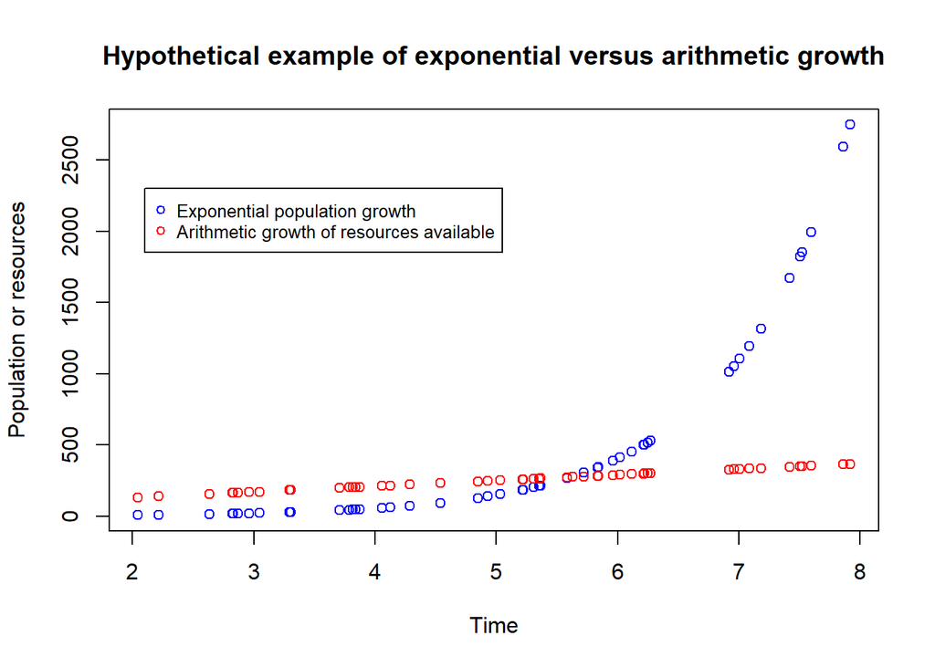

```r
# Generate random numbers from an uniform distribution (runif(n, min, max))
x <- runif(50,2,8)

# Plot hypothetical exponential and linear growth patterns
plot(x,exp(x), lty=1, col = "blue", main="Hypothetical example of exponential versus arithmetic growth", xlab="Time",
     ylab="Population or resources")
points(x,50+(40*x),col="red")
legend(2.1, 2300, legend=c("Exponential population growth", "Arithmetic growth of resources available"),
       col=c("blue", "red"), cex=0.8, pch=c(21,1))
```

### 2.3.2 When are simple population models used in biological analyses?

Now let’s see when simple models such as the exponential growth model are used in biology. In some situations, we can disregard factors which limit the growth of populations, such as resource availability, interactions between species, and relocation of individuals. Here are some examples:

- **Experimental settings**: In lab conditions, we remove as many factors as possible which could potentially interfere with the growth of our model species, so that we can focus on understanding the effects of our selected explanatory variables during experiments. In our lab, we work with duckweeds, a group of small aquatic plant species. In the photos below, you can see the difference between natural and lab conditions. In lab settings, duckweeds can achieve unlimited growth which can be modelled by exponential growth models. This is because a single species is selected and sterilized, eliminating potential sources of disease and all of the competition naturally seen between duckweed species (different sizes of fronds - leaf-like shapes - represent different duckweed species), and with other species, such as algae. In labs, other factors are also controlled to provide optimal conditions, such as light, nutrition, and temperature.

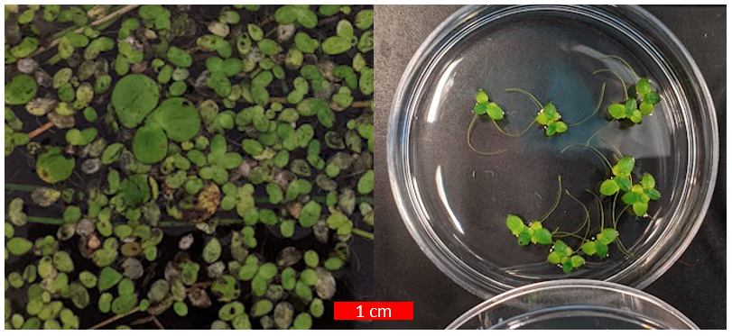

Duckweeds in the field (left) and in lab conditions (right); left: *Spirodela polyrhiza* (larger fronds) and (probably) *Lemna minor*; right: *Landoltia punctata*

- **Expanding invasive species**: Following the introduction of an invasive species, its spread is enabled by an exponential population growth (Shigesada & Kawasaki, 1997) due to the availability of resources and/or absence of natural enemies. Spotted knapweeds, for example, were accidentally introduced to North America in the 1980s with agricultural seeds and soil discarded from ship ballast from Eurasia. This species is considered problematic because it quickly replaces livestock pasture and reduces biodiversity in affected sites (Minnesota Department of Agriculture, 2023). A modelling study considering the life history of knapweeds found that exponential growth following the introduction of invading populations can be observed for about 2 years (Jacobs & Sheley, 1998). Thus, exponential models are useful for modelling the behaviour of invading species.

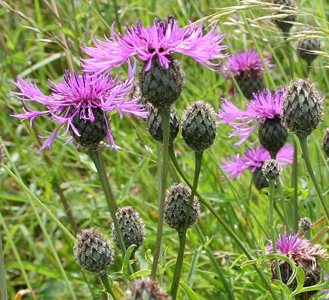

Common knapweed (*Centaurea nigra*) by Kate Jewell (https://commons.wikimedia.org/wiki/File:Common_knapweed_%28Centaurea_nigra%29_-_geograph.org.uk_-_492672.jpg), Creative Commons License CC-BY-SA-2.0

- **Management of species at risk of extinction**: Well-managed species will have little limitation to growth due to abundant resources and small population sizes, resulting in exponential growth rates. This was observed following management strategies to recover endangered crane populations in both North America and Japan. Whooping cranes (*Grus americana*) are the largest North American birds which became severely endangered with a population of 21 birds in 1952, as well as the red-crowned crane of Hokkaido (*Grus japonensis*) in Japan, with 33 individuals at this same year. Since then, management efforts such as federal protection and creating wildlife refuges ensured an exponential growth to bird populations, achieving 506 North American cranes and 1,900 Japanese cranes in 2020. The much faster rate at which Japanese cranes are growing is attributed to an additional management strategy consisting of artificially feeding birds during periods of food scarcity which was not implemented in North America (Gronewold, 2021).

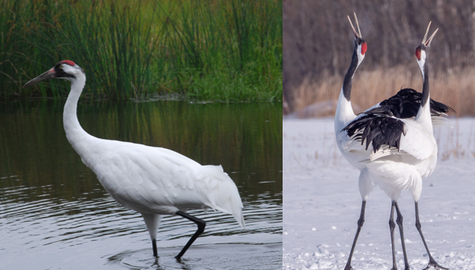

Endangered cranes: Whooping crane to the left and red-crowned crane to the right, by CheepShot (https://commons.wikimedia.org/wiki/File:Whooping_Crane_%283873713594%29.jpg), Creative Commons License CC-BY-2.0, and Peter Batty (https://www.flickr.com/photos/ebatty/50772105027), Creative Commons License CC BY-NC-SA 2.0